# Visual Multivariate Analysis with Parallel Coordinates Plot

Author

Cheng yuanyuan

## 1 Overview

Parallel coordinates plot is a useful visual analytics method for exploring multivariate numerical data. Instead of looking at one variable at a time, this method places several numerical variables on parallel vertical axes and connects each observation across the axes.

This is especially useful when the analyst wants to compare many variables together, detect possible clusters, identify unusual observations, and understand how different indicators move across countries or groups.

In this hands-on exercise, the World Happiness 2018 data will be used to demonstrate both static and interactive parallel coordinates plots.

The main learning points are:

- how to create static parallel coordinates plots using `ggparcoord()` from the **GGally** package;
- how to scale variables so that different numerical ranges can be compared fairly;
- how to use grouping, transparency, boxplots, facets, and axis-label adjustment;
- how to create interactive parallel coordinates plots using the **parallelPlot** package.

## 2 Installing and launching R packages

```r
# Install pacman if it is not available
if (!requireNamespace("pacman", quietly = TRUE)) {
  install.packages("pacman")
}

# Load required packages
pacman::p_load(
  tidyverse,
  GGally,
  parallelPlot
)
```

## 3 Data preparation

The data file used in this exercise is:

```
data/WHData-2018.csv
```

The code below imports the CSV file into R and saves it as a tibble called `wh`.

```r
# Check whether the data file exists before reading it
if (!file.exists("data/WHData-2018.csv")) {
  stop("The file data/WHData-2018.csv is missing. Please put WHData-2018.csv inside the data folder.")
}

wh <- read_csv("data/WHData-2018.csv")

glimpse(wh)
```

```
Rows: 156
Columns: 12
$ Country                        <chr> "Albania", "Bosnia and Herzegovina", "B…
$ Region                         <chr> "Central and Eastern Europe", "Central …
$ `Happiness score`              <dbl> 4.586, 5.129, 4.933, 5.321, 6.711, 5.73…
$ `Whisker-high`                 <dbl> 4.695, 5.224, 5.022, 5.398, 6.783, 5.81…
$ `Whisker-low`                  <dbl> 4.477, 5.035, 4.844, 5.244, 6.639, 5.66…
$ Dystopia                       <dbl> 1.462, 1.883, 1.219, 1.769, 2.494, 1.45…
$ `GDP per capita`               <dbl> 0.916, 0.915, 1.054, 1.115, 1.233, 1.20…
$ `Social support`               <dbl> 0.817, 1.078, 1.515, 1.161, 1.489, 1.53…
$ `Healthy life expectancy`      <dbl> 0.790, 0.758, 0.712, 0.737, 0.854, 0.73…
$ `Freedom to make life choices` <dbl> 0.419, 0.280, 0.359, 0.380, 0.543, 0.55…
$ Generosity                     <dbl> 0.149, 0.216, 0.064, 0.120, 0.064, 0.08…
$ `Perceptions of corruption`    <dbl> 0.032, 0.000, 0.009, 0.039, 0.034, 0.17…
```

The first few rows are shown below.

```r
head(wh)
```

```
# A tibble: 6 × 12
  Country         Region `Happiness score` `Whisker-high` `Whisker-low` Dystopia
  <chr>           <chr>              <dbl>          <dbl>         <dbl>    <dbl>
1 Albania         Centr…              4.59           4.70          4.48     1.46
2 Bosnia and Her… Centr…              5.13           5.22          5.04     1.88
3 Bulgaria        Centr…              4.93           5.02          4.84     1.22
4 Croatia         Centr…              5.32           5.40          5.24     1.77
5 Czech Republic  Centr…              6.71           6.78          6.64     2.49
6 Estonia         Centr…              5.74           5.82          5.66     1.46
# ℹ 6 more variables: `GDP per capita` <dbl>, `Social support` <dbl>,
#   `Healthy life expectancy` <dbl>, `Freedom to make life choices` <dbl>,
#   Generosity <dbl>, `Perceptions of corruption` <dbl>
```

## 4 Static parallel coordinates plot

### 4.1 Simple parallel coordinates plot

The first plot uses only the selected numerical variables from the dataset. In this example, columns 7 to 12 are used because they contain the main World Happiness indicators.

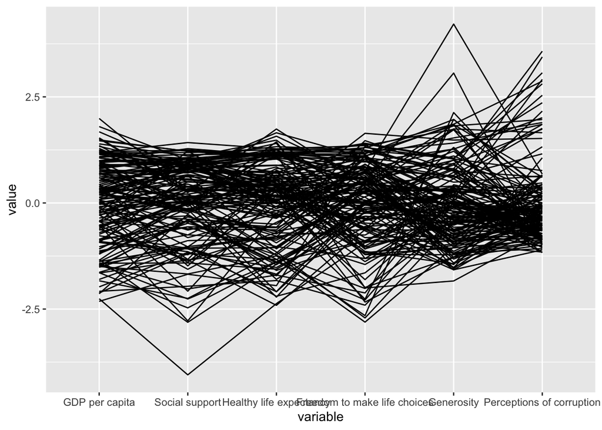

```r
ggparcoord(
  data = wh,
  columns = c(7:12)
)
```

This basic version is technically correct, but it is difficult to interpret because all lines use the same visual treatment and the variables are not yet grouped by region.

### 4.2 Parallel coordinates plot with grouping, scaling and boxplot

The next version improves the plot by adding several important arguments.

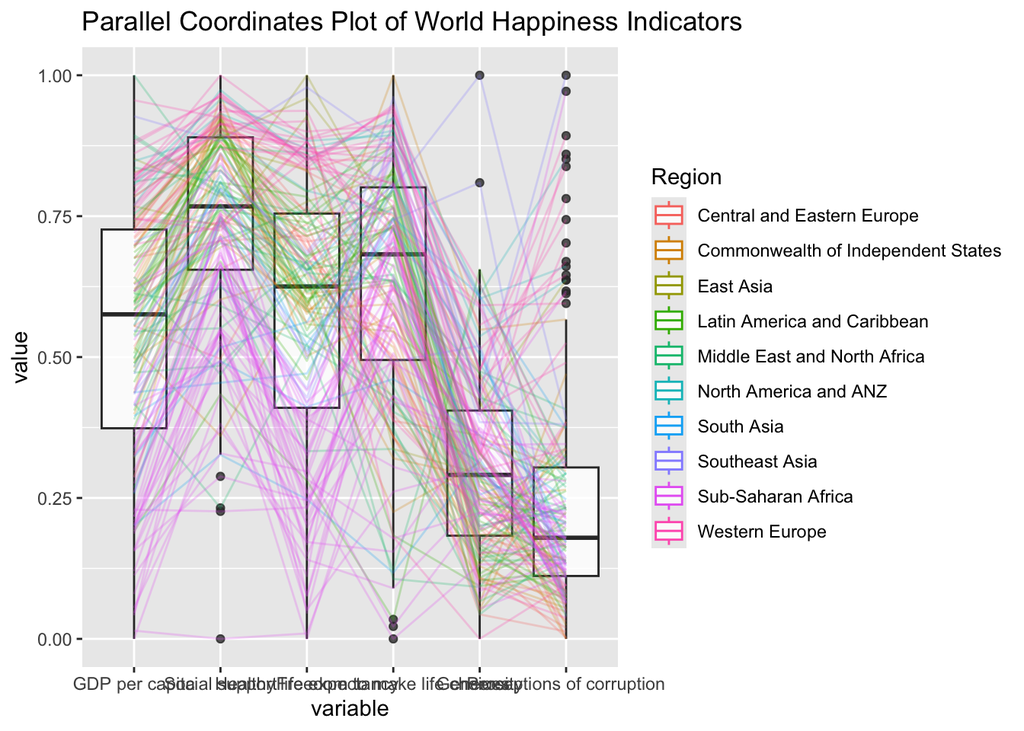

```r
ggparcoord(
  data = wh,
  columns = c(7:12),
  groupColumn = 2,
  scale = "uniminmax",
  alphaLines = 0.25,
  boxplot = TRUE,
  title = "Parallel Coordinates Plot of World Happiness Indicators"
)
```

Important arguments used above:

- `groupColumn = 2` colours the lines by the second column, which is the geographical region.
- `scale = "uniminmax"` rescales each variable from 0 to 1, so variables with different units can be compared on the same plot.
- `alphaLines = 0.25` makes the lines more transparent, reducing visual clutter.
- `boxplot = TRUE` adds a boxplot summary for each variable.
- `title` adds a clear chart title.

This version is more useful because it allows regional patterns to appear more clearly.

### 4.3 Parallel coordinates plot with facets

Because the plot contains many regions, a single chart can still be visually crowded. Faceting splits the chart into smaller panels by region.

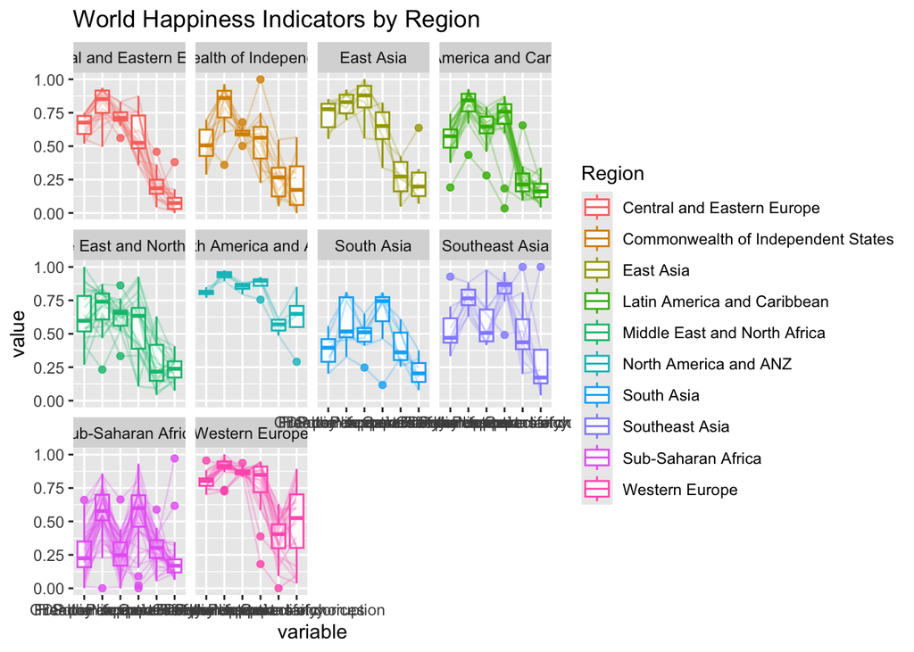

```r
ggparcoord(
  data = wh,
  columns = c(7:12),
  groupColumn = 2,
  scale = "uniminmax",
  alphaLines = 0.25,
  boxplot = TRUE,
  title = "World Happiness Indicators by Region"
) +
  facet_wrap(~ Region)
```

The faceted version makes it easier to compare patterns within each region separately. However, some x-axis labels may overlap because the variable names are long.

### 4.4 Rotating x-axis labels

To improve readability, the x-axis labels can be rotated using `theme()`.

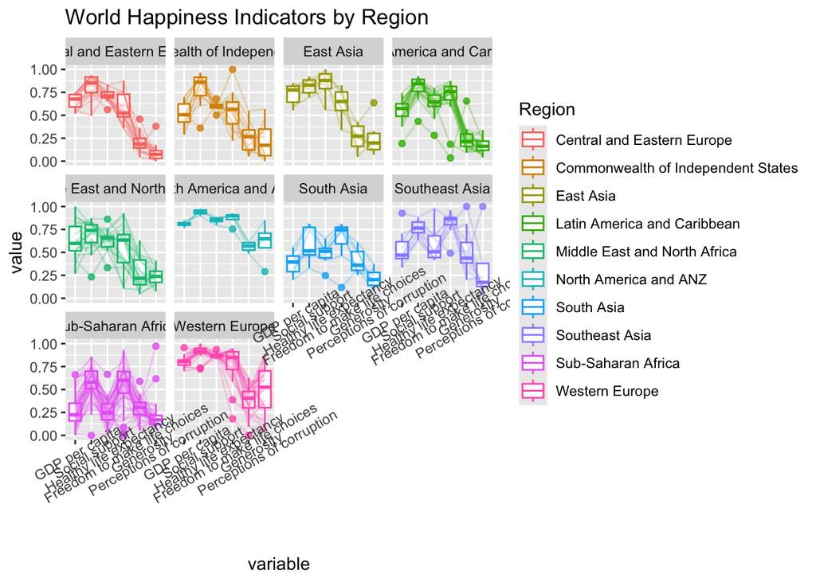

```r
ggparcoord(
  data = wh,
  columns = c(7:12),
  groupColumn = 2,
  scale = "uniminmax",
  alphaLines = 0.25,
  boxplot = TRUE,
  title = "World Happiness Indicators by Region"
) +
  facet_wrap(~ Region) +
  theme(
    axis.text.x = element_text(angle = 30)
  )
```

Rotating the labels helps, but the text position is still not ideal because the labels can be too close to the plot area.

### 4.5 Adjusting rotated x-axis labels

The final static version adjusts the horizontal justification of the rotated labels.

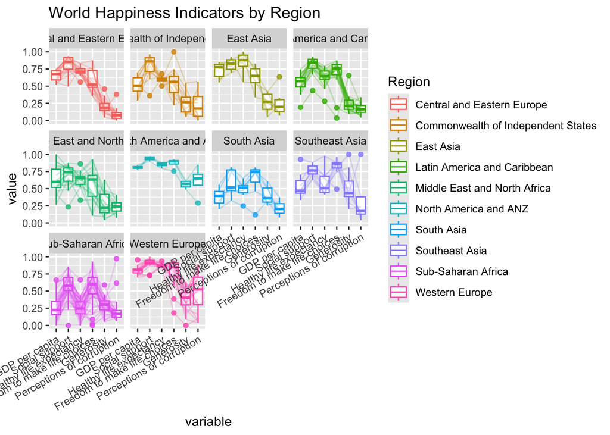

```r
ggparcoord(
  data = wh,
  columns = c(7:12),
  groupColumn = 2,
  scale = "uniminmax",
  alphaLines = 0.25,
  boxplot = TRUE,
  title = "World Happiness Indicators by Region"
) +
  facet_wrap(~ Region) +
  theme(
    axis.text.x = element_text(angle = 30, hjust = 1)
  )
```

This is the cleanest static version because it combines grouping, scaling, transparency, boxplots, faceting, and readable axis labels.

## 5 Interactive parallel coordinates plot

The **parallelPlot** package can be used to create an interactive parallel coordinates plot. This is useful because the viewer can explore variables more flexibly.

Before plotting, a smaller data frame is created by selecting the happiness score and the main numerical indicators.

```r
wh_interactive <- wh %>%
  select(
    "Happiness score",
    c(7:12)
  )

glimpse(wh_interactive)
```

```
Rows: 156
Columns: 7
$ `Happiness score`              <dbl> 4.586, 5.129, 4.933, 5.321, 6.711, 5.73…
$ `GDP per capita`               <dbl> 0.916, 0.915, 1.054, 1.115, 1.233, 1.20…
$ `Social support`               <dbl> 0.817, 1.078, 1.515, 1.161, 1.489, 1.53…
$ `Healthy life expectancy`      <dbl> 0.790, 0.758, 0.712, 0.737, 0.854, 0.73…
$ `Freedom to make life choices` <dbl> 0.419, 0.280, 0.359, 0.380, 0.543, 0.55…
$ Generosity                     <dbl> 0.149, 0.216, 0.064, 0.120, 0.064, 0.08…
$ `Perceptions of corruption`    <dbl> 0.032, 0.000, 0.009, 0.039, 0.034, 0.17…
```

### 5.1 Basic interactive plot

```r
parallelPlot(
  wh_interactive,
  width = 800,
  height = 450
)
```

[interactive chart not shown]

The basic interactive chart allows the user to explore the relationship between the happiness score and the selected indicators.

### 5.2 Rotating axis titles

Some variable names are long. `rotateTitle = TRUE` rotates the axis titles and makes the chart easier to read.

```r
parallelPlot(
  wh_interactive,
  rotateTitle = TRUE,
  width = 800,
  height = 450
)
```

[interactive chart not shown]

### 5.3 Changing the continuous colour scheme

The colour scheme can be changed using the `continuousCS` argument.

```r
parallelPlot(
  wh_interactive,
  rotateTitle = TRUE,
  continuousCS = "YlOrRd",
  width = 800,
  height = 450
)
```

[interactive chart not shown]

This version uses a yellow-orange-red colour scheme, which helps show value intensity more clearly when an axis is selected.

### 5.4 Adding histograms to the axes

Histograms can be displayed along the axes by using the `histoVisibility` argument.

```r
histoVisibility <- rep(TRUE, ncol(wh_interactive))

parallelPlot(
  wh_interactive,
  rotateTitle = TRUE,
  histoVisibility = histoVisibility,
  width = 800,
  height = 450
)
```

[interactive chart not shown]

The histogram view gives extra distribution information for each variable, so the chart is not only showing multivariate patterns but also the shape of each variable’s distribution.

## 6 Summary

Parallel coordinates plot is mainly an exploratory visual analytics technique. It is not always suitable for simple business presentation because it can look complex to a general audience. However, for data exploration, it is useful because it allows many numerical variables to be compared at the same time.

For this exercise, the most important technical points are:

- `ggparcoord()` creates static parallel coordinates plots;
- `columns = c(7:12)` selects the numerical variables to plot;
- `groupColumn` colours observations by a categorical grouping variable;
- `scale = "uniminmax"` rescales each variable from 0 to 1;
- `alphaLines` reduces visual clutter;
- `boxplot = TRUE` adds summary distribution information;
- `facet_wrap()` splits the plot by region;
- `theme(axis.text.x = element_text(angle = 30, hjust = 1))` improves axis-label readability;
- `parallelPlot()` creates interactive parallel coordinates plots;
- `rotateTitle`, `continuousCS`, and `histoVisibility` improve the interactive chart.

## 7 References

- R for Visual Analytics, Chapter 15: Visual Multivariate Analysis with Parallel Coordinates Plot.
- GGally package: `ggparcoord()`.
- parallelPlot package: `parallelPlot()`.